# CIND119 - Group Project

10/04/2021

## Memebers

Patrick Litte, patrick.little@ryerson.ca  
Manjola Chiappetta, m1chiappetta@ryerson.ca

## Summary

###Tools

This project will leverage R for the exploratory data analysis, data preprocessing, predictive modeling, and model evaluation. We will use the tidymodels framework to implement our predictive modelling, and model evaluation, and we will use the DataExplorer package to aid in exploratory data analysis.

## Workload Distribution

| Member Name | List of Tasks Preformed |
| --- | --- |
| Patrick Little | - some tasks |
| Manjola Chiappetta | - some tasks |

## Exploratory Data Analysis

In this section we will: - Look at the attribute types in the dataset - Find and missing values - Examine the pairwise association between our variables - Find max,min,mean and standard deviation of the atttributes - Determine any outlier values for the attributes under consideration - Analyze the distribution of numeric attributes

To begin our exploratory data analysis we can use the data explorer R package to generate an easy to consume overview of our dataset. In this plot one can observe that there are a mix of discrete and continuous variables in our dataset. Additionally we can observe that there is no missing data observations contained within our dataset.

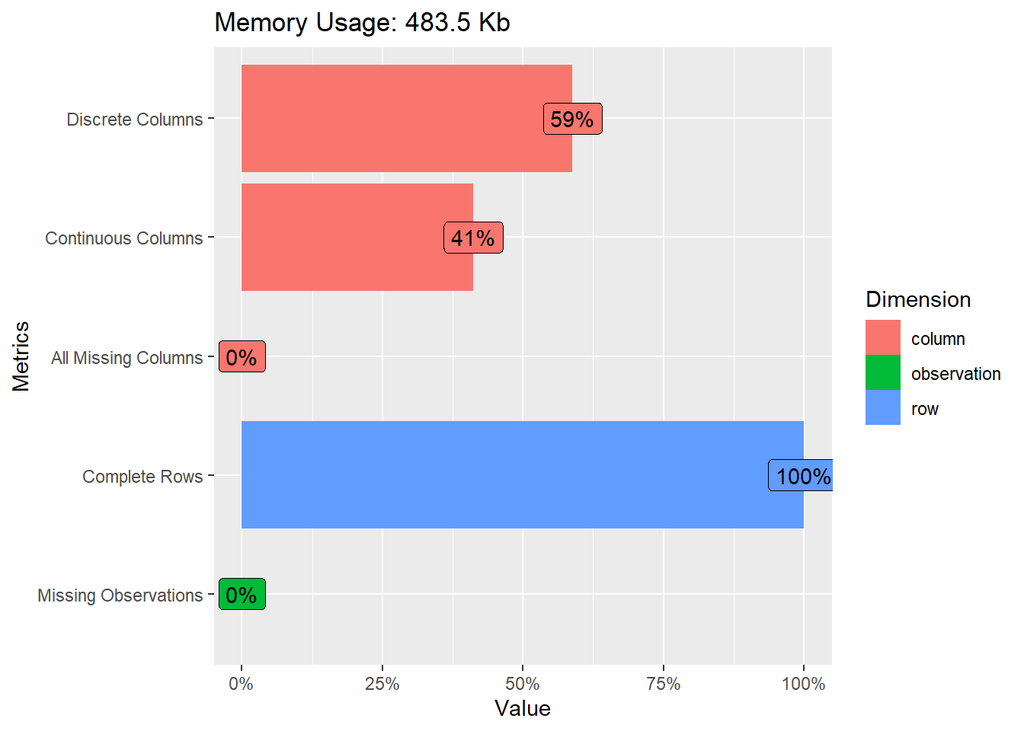

```r
bank<-read.csv("https://raw.githubusercontent.com/PatLittle/CIND119-group-project/main/bank_marketing/bank.csv")
plot_intro(bank)
```

Looking at the individual columns of our dataset, one can observe their are 17 variables in our dataset. Age, balance, day, duration, campaign, duration, pdays, and previous are of type integer. Job, marital, education, default, housing, loan, contact, month, poutcome, and y are of type character.

```r
plot_str(bank, type="d")
```

[output not shown]

We can examine the values of our character variables to determine if character is the appropriate data type for each of the variables. If a variable of type character contains a limited number of possible values, then converting that variable to be of type factor will allow our predictive models to interpret that data without significant additional prepossessing. If those variables contain free form text without a controlled vocabulary for that variable, then likely additional natural language processing techniques such as stemming and lemmatizaion, along with other preprocessing or feature engineering may be required before those variables would offer significant predictive value to our models.

```r
job<-levels(as.factor(bank$job))
marital<-levels(as.factor(bank$marital))
education<-levels(as.factor(bank$education))
default<-levels(as.factor(bank$default))
housing<-levels(as.factor(bank$housing))
loan<-levels(as.factor(bank$loan))
contact<-levels(as.factor(bank$contact))
month<-levels(as.factor(bank$month))
poutcome<-levels(as.factor(bank$poutcome))
y<-levels(as.factor(bank$y))

na.pad <- function(x,len){
    x[1:len]
}

makePaddedDataFrame <- function(l,...){
    maxlen <- max(sapply(l,length))
    data.frame(lapply(l,na.pad,len=maxlen),...)
}

a = job
b = marital
c = education
d = default
e = loan
f = contact
g = month
h = poutcome
j = y

data_dict<-makePaddedDataFrame(list("Job"=a,"Marital"=b,"Education"=c,"Default"=d,"Loan"=e,"Contact"=f,"Month"=g,"pOutcome"=h,"y"=j))

data_dict %>% na.replace("")
```

```
##              Job  Marital Education Default Loan   Contact Month pOutcome   y
## 1         admin. divorced   primary      no   no  cellular   apr  failure  no
## 2    blue-collar  married secondary     yes  yes telephone   aug    other yes
## 3   entrepreneur   single  tertiary                unknown   dec  success
## 4      housemaid            unknown                          feb  unknown
## 5     management                                             jan
## 6        retired                                             jul
## 7  self-employed                                             jun
## 8       services                                             mar
## 9        student                                             may
## 10    technician                                             nov
## 11    unemployed                                             oct
## 12       unknown                                             sep
```

```r
options(knitr.kable.NA = '')
kable(data_dict, caption="Character Variables with all Existing Values")
```

Character Variables with all Existing Values

| Job | Marital | Education | Default | Loan | Contact | Month | pOutcome | y |
| --- | --- | --- | --- | --- | --- | --- | --- | --- |
| admin. | divorced | primary | no | no | cellular | apr | failure | no |
| blue-collar | married | secondary | yes | yes | telephone | aug | other | yes |
| entrepreneur | single | tertiary |  |  | unknown | dec | success |  |
| housemaid |  | unknown |  |  |  | feb | unknown |  |
| management |  |  |  |  |  | jan |  |  |
| retired |  |  |  |  |  | jul |  |  |
| self-employed |  |  |  |  |  | jun |  |  |
| services |  |  |  |  |  | mar |  |  |
| student |  |  |  |  |  | may |  |  |
| technician |  |  |  |  |  | nov |  |  |
| unemployed |  |  |  |  |  | oct |  |  |
| unknown |  |  |  |  |  | sep |  |  |

Examining our table above of each of the variables of type character with the universe of existing values for each variables, serving as a simple data dictionary, we can determine that this is a controlled vocabulary and there is not unstructured text in these fields. Since there is a controlled vocabulary being used with these variables, we will convert these variables to be of type factor.

```r
bank_clean<- bank %>% mutate_if(is.character, factor)
```

We can then examine the pairwise association between all of the variables in the dataframe. In this analysis we will use Spearman Correlation to measure the association between our numeric variables, Cramer’s V for our nominal factor data, and ANOVA to compare numeric data with factor data.

```r
require(rcompanion)
```

```r
# Calculate a pairwise association between all variables in a data-frame. In particular nominal vs nominal with Chi-square, numeric vs numeric with Spearman correlation, and nominal vs numeric with ANOVA.
# Adopted from https://stackoverflow.com/a/52557631/590437
mixed_assoc = function(df, cor_method="spearman", adjust_cramersv_bias=TRUE){
    df_comb = expand.grid(names(df), names(df),  stringsAsFactors = F) %>% set_names("X1", "X2")

    is_nominal = function(x) class(x) %in% c("factor", "character")
    # https://community.rstudio.com/t/why-is-purr-is-numeric-deprecated/3559
    # https://github.com/r-lib/rlang/issues/781
    is_numeric <- function(x) { is.integer(x) || is_double(x)}

    f = function(xName,yName) {
        x =  pull(df, xName)
        y =  pull(df, yName)

        result = if(is_nominal(x) && is_nominal(y)){
            # use bias corrected cramersV as described in https://rdrr.io/cran/rcompanion/man/cramerV.html
            cv = cramerV(as.character(x), as.character(y), bias.correct = adjust_cramersv_bias)
            data.frame(xName, yName, assoc=cv, type="cramersV")

        }else if(is_numeric(x) && is_numeric(y)){
            correlation = cor(x, y, method=cor_method, use="complete.obs")
            data.frame(xName, yName, assoc=correlation, type="correlation")

        }else if(is_numeric(x) && is_nominal(y)){
            # from https://stats.stackexchange.com/questions/119835/correlation-between-a-nominal-iv-and-a-continuous-dv-variable/124618#124618
            r_squared = summary(lm(x ~ y))$r.squared
            data.frame(xName, yName, assoc=sqrt(r_squared), type="anova")

        }else if(is_nominal(x) && is_numeric(y)){
            r_squared = summary(lm(y ~x))$r.squared
            data.frame(xName, yName, assoc=sqrt(r_squared), type="anova")

        }else {
            warning(paste("unmatched column type combination: ", class(x), class(y)))
        }

        # finally add complete obs number and ratio to table
        result %>% mutate(complete_obs_pairs=sum(!is.na(x) & !is.na(y)), complete_obs_ratio=complete_obs_pairs/length(x)) %>% rename(x=xName, y=yName)
    }

    # apply function to each variable combination
    map2_df(df_comb$X1, df_comb$X2, f)
}

cor_data<-mixed_assoc(bank_clean) %>% subset(assoc<0.99999) %>% arrange(desc(abs(assoc)))
kable(cor_data[1:16,1:4],row.names = F, caption = "Mixed Data Types Correlation/Association")
```

Mixed Data Types Correlation/Association

| x | y | assoc | type |
| --- | --- | --- | --- |
| previous | pdays | 0.9862904 | correlation |
| pdays | previous | 0.9862904 | correlation |
| poutcome | pdays | 0.8759717 | anova |
| pdays | poutcome | 0.8759717 | anova |
| poutcome | previous | 0.6850125 | anova |
| previous | poutcome | 0.6850125 | anova |
| month | contact | 0.5131000 | cramersV |
| contact | month | 0.5131000 | cramersV |
| job | age | 0.5061504 | anova |
| age | job | 0.5061504 | anova |
| month | housing | 0.4878000 | cramersV |
| housing | month | 0.4878000 | cramersV |
| education | job | 0.4551000 | cramersV |
| job | education | 0.4551000 | cramersV |
| month | day | 0.4490406 | anova |
| day | month | 0.4490406 | anova |

Looking at the top 8 pairs of variables in our pairwise comparison sorted by the absolute value of the association measure, we can see that the variables Previous and pDays seem to have a high measure of correlation. With a Spearman value of 0.986, we can state there is a highly monotonic relation between the variables. In this metric we are assessing if the variables move in the same direction, however this relation could be have one of a number of non-linear relation types such as exponential, logistic, etc.

Looking at the relations between our numeric variables with a different metric, one can use the Pearson correlation to assess the linearity of the relationships. With an R value of 0.58, the relation between the pDays and Previous variables is a moderate positive correlation. Since the R value is in a moderate range, there is still likely predictive value in including both variables in our models.

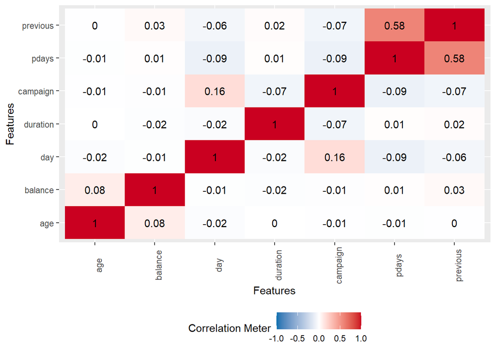

```r
plot_correlation(bank_clean, type = "c", cor_args = list("method"="pearson"))
```

We can then look for outliers in our numeric variables. Comparing the median, mean, min, and max values for our numeric variables, we can observe that many of our numeric variables each have max or min values that vary by an order of magnitude between the IQR and the min/max value. This warrants furthur exploration into the outliers within the dataset.

```r
kable(summary(bank_clean))
```

|  | age | job | marital | education | default | balance | housing | loan | contact | day | month | duration | campaign | pdays | previous | poutcome | y |
| --- | --- | --- | --- | --- | --- | --- | --- | --- | --- | --- | --- | --- | --- | --- | --- | --- | --- |
|  | Min. :19.00 | management :969 | divorced: 528 | primary : 678 | no :4445 | Min. :-3313 | no :1962 | no :3830 | cellular :2896 | Min. : 1.00 | may :1398 | Min. : 4 | Min. : 1.000 | Min. : -1.00 | Min. : 0.0000 | failure: 490 | no :4000 |
|  | 1st Qu.:33.00 | blue-collar:946 | married :2797 | secondary:2306 | yes: 76 | 1st Qu.: 69 | yes:2559 | yes: 691 | telephone: 301 | 1st Qu.: 9.00 | jul : 706 | 1st Qu.: 104 | 1st Qu.: 1.000 | 1st Qu.: -1.00 | 1st Qu.: 0.0000 | other : 197 | yes: 521 |
|  | Median :39.00 | technician :768 | single :1196 | tertiary :1350 |  | Median : 444 |  |  | unknown :1324 | Median :16.00 | aug : 633 | Median : 185 | Median : 2.000 | Median : -1.00 | Median : 0.0000 | success: 129 |  |
|  | Mean :41.17 | admin. :478 |  | unknown : 187 |  | Mean : 1423 |  |  |  | Mean :15.92 | jun : 531 | Mean : 264 | Mean : 2.794 | Mean : 39.77 | Mean : 0.5426 | unknown:3705 |  |
|  | 3rd Qu.:49.00 | services :417 |  |  |  | 3rd Qu.: 1480 |  |  |  | 3rd Qu.:21.00 | nov : 389 | 3rd Qu.: 329 | 3rd Qu.: 3.000 | 3rd Qu.: -1.00 | 3rd Qu.: 0.0000 |  |  |
|  | Max. :87.00 | retired :230 |  |  |  | Max. :71188 |  |  |  | Max. :31.00 | apr : 293 | Max. :3025 | Max. :50.000 | Max. :871.00 | Max. :25.0000 |  |  |
|  |  | (Other) :713 |  |  |  |  |  |  |  |  | (Other): 571 |  |  |  |  |  |  |

Looking at a box plot of our numeric variables, we can get a sense for the extent of the distribution of outliers in each variable.

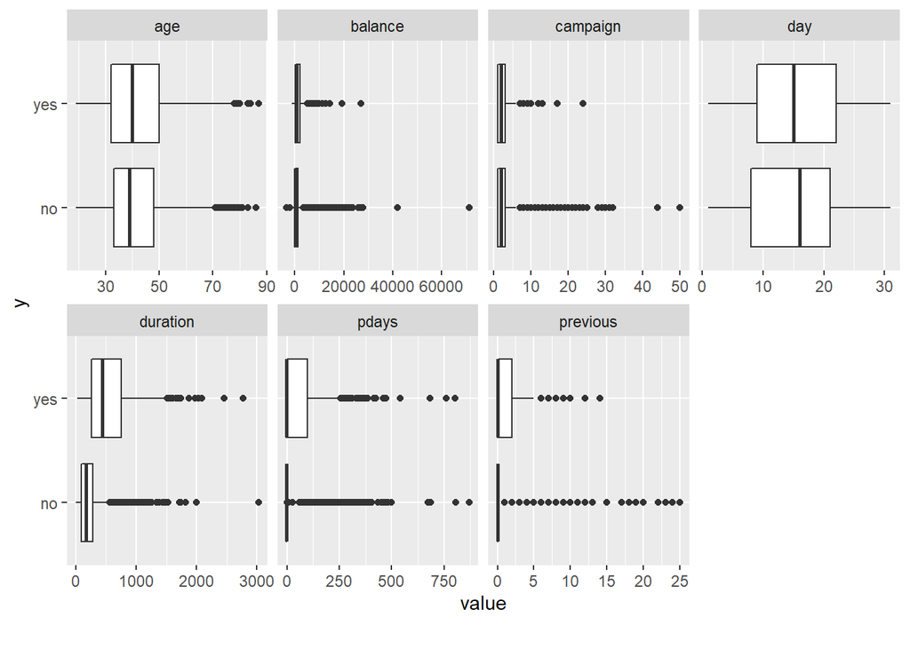

```r
plot_boxplot(bank_clean, by="y")
```

We can then remove outliers from the dataset, using the standard dentition of 1.5*IQR.

```r
age_out<-boxplot(bank_clean$age,plot=F)$out
bal_out<-boxplot(bank_clean$balance,plot=F)$out
campaign_out<-boxplot(bank_clean$campaign,plot=F)$out
duration_out<-boxplot(bank_clean$duration,plot=F)$out
pdays_out<-boxplot(bank_clean$pdays,plot=F)$out
prev_out<-boxplot(bank_clean$previous,plot=F)$out

bank_clean <- bank_clean[-which(bank_clean$age %in% age_out),]
bank_clean <- bank_clean[-which(bank_clean$balance %in% bal_out),]
bank_clean <- bank_clean[-which(bank_clean$campaign %in% campaign_out),]
bank_clean <- bank_clean[-which(bank_clean$duration %in% duration_out),]
bank_clean <- bank_clean[-which(bank_clean$pdays %in% pdays_out),]
bank_clean <- bank_clean[-which(bank_clean$previous %in% prev_out),]

head(bank_clean)
```

```
##  [1] age       job       marital   education default   balance   housing
##  [8] loan      contact   day       month     duration  campaign  pdays
## [15] previous  poutcome  y
## <0 rows> (or 0-length row.names)
```

Using a standard outlier removal approach on all of our predictor variables results in zero rows left in our dataset for analysis. Therefore, for our modeling instead of manually removing outliers from the data, we will apply a YeoJohnson transform on our numeric variables. This should serve as a adequate method to both mitigate the effect of outliers, as well as contribute to normalizing the dataset.

For our variable Day, although the data is encoded as a numeric variable, this represents more of a factor variables, therefore we will convert this variable to type factor such that it does not receive a YeoJohnson transform during our model preprocessing.

```r
bank_clean<- bank %>% mutate_if(is.character, factor)
bank_clean$day<-as.factor(bank_clean$day)
```

## Predictive Modeling / Classification

### Decision Tree

```r
###Decision Tree


tic()


set.seed(888)
bank_split <- initial_split(bank_clean, prop = 0.75,
                             strata = y)

bank_training <- bank_split %>% training()
bank_test <- bank_split %>% testing()
bank_folds <- vfold_cv(bank_training, v = 10)



bank_recipe <- recipe(y ~ ., data = bank_training) %>%
  step_YeoJohnson(all_numeric(),-all_predictors())



bank_clean_baked<-bank_recipe %>%
  prep() %>%
  bake(new_data = bank_training)

tree_model <- decision_tree(cost_complexity = tune(),
                            tree_depth = tune(),
                            min_n = tune()) %>%
  set_engine('rpart') %>%
  set_mode('classification')

tree_workflow <- workflow() %>%
  add_model(tree_model) %>%
  add_recipe(bank_recipe)

tree_grid <- grid_latin_hypercube(cost_complexity(),
                          tree_depth(),
                          min_n(),
                          size = 60)

set.seed(888)


tree_tuning <- tree_workflow %>%
  tune_grid(resamples = bank_folds,
            grid = tree_grid)
tree_tuning %>% show_best('roc_auc')
```

```
## # A tibble: 5 x 9
##   cost_complexity tree_depth min_n .metric .estimator  mean     n std_err
##             <dbl>      <int> <int> <chr>   <chr>      <dbl> <int>   <dbl>
## 1  0.00179                12    35 roc_auc binary     0.846    10 0.00973
## 2  0.000116               12    38 roc_auc binary     0.833    10 0.0121
## 3  0.000142               11    38 roc_auc binary     0.833    10 0.0121
## 4  0.000000000680          9    26 roc_auc binary     0.831    10 0.0153
## 5  0.0000000102           13    33 roc_auc binary     0.831    10 0.0132
## # ... with 1 more variable: .config <chr>
```

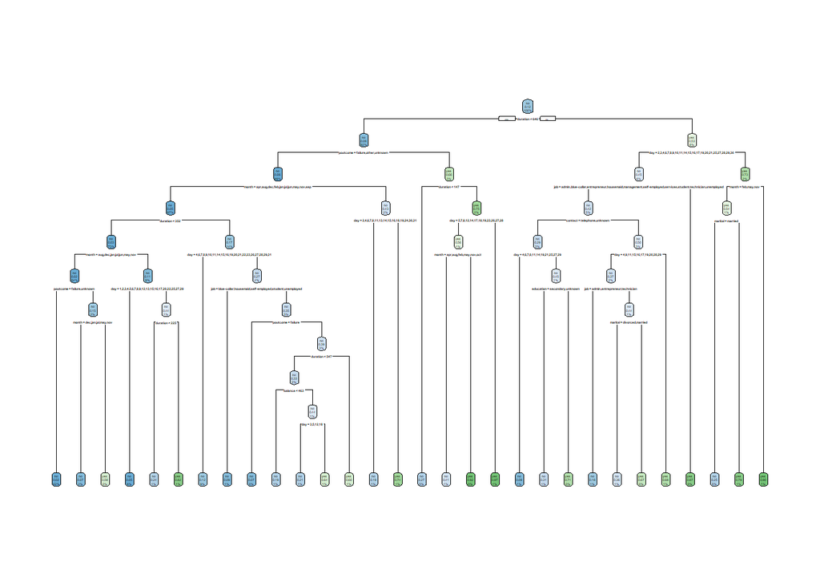

```r
best_tree <- tree_tuning %>%
  select_best(metric = 'roc_auc')


final_tree_workflow <- tree_workflow %>%
  finalize_workflow(best_tree)


tree_wf_fit <- final_tree_workflow %>%
  fit(data = bank_training)

tree_fit <- tree_wf_fit %>%
  pull_workflow_fit()


rpart.plot(tree_fit$fit, roundint = F)
```

```r
tree_last_fit <- final_tree_workflow %>%
  last_fit(bank_split)

tree_last_fit %>% collect_metrics()
```

```
## # A tibble: 2 x 4
##   .metric  .estimator .estimate .config
##   <chr>    <chr>          <dbl> <chr>
## 1 accuracy binary         0.876 Preprocessor1_Model1
## 2 roc_auc  binary         0.816 Preprocessor1_Model1
```

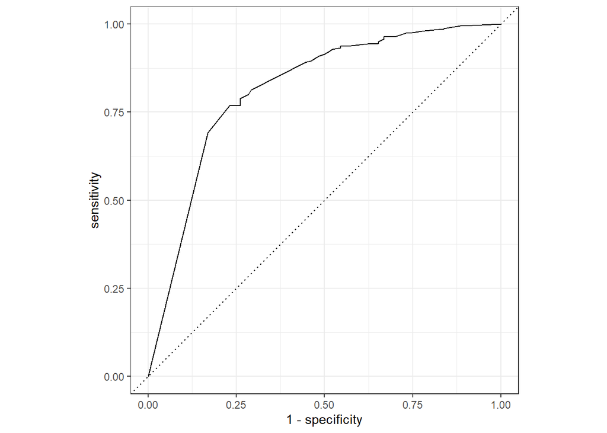

```r
tree_last_fit %>% collect_predictions() %>%
  roc_curve(truth  = y, estimate = .pred_no) %>%
  autoplot()
```

```r
tree_predictions <- tree_last_fit %>% collect_predictions()

conf_mat(tree_predictions, truth = y, estimate = .pred_class)
```

```
##           Truth
## Prediction  no yes
##        no  945  85
##        yes  55  45
```

```r
toc()
```

```
## 212.39 sec elapsed
```

### Naive Bayes

```r
tic()

set.seed(888)
nb_split <- initial_split(bank_clean, prop = 0.75,
                            strata = y)

nb_training <- nb_split %>% training()
nb_test <- nb_split %>% testing()
nb_folds <- vfold_cv(nb_training, v = 10)

nb_recipe <- recipe(y ~ ., data = nb_training) %>%
  step_YeoJohnson(all_numeric(),-all_predictors())



nb_wf <- workflow() %>%
  add_recipe(nb_recipe)

library(discrim)
nb_spec <- naive_Bayes() %>%
  set_mode("classification") %>%
  set_engine("naivebayes")

nb_spec
```

```
## Naive Bayes Model Specification (classification)
##
## Computational engine: naivebayes
```

```r
nb_fit <- nb_wf %>%
  add_model(nb_spec) %>%
  fit(data = nb_training)

nb_wf_final <-  workflow() %>%
  add_recipe(nb_recipe) %>%
  add_model(nb_spec)

nb_rs <- fit_resamples(
  nb_wf_final,
  nb_folds,
  control = control_resamples(save_pred = TRUE)
)


nb_last_fit <- nb_wf_final %>%
  last_fit(nb_split)

nb_last_fit %>% collect_metrics()
```

```
## # A tibble: 2 x 4
##   .metric  .estimator .estimate .config
##   <chr>    <chr>          <dbl> <chr>
## 1 accuracy binary         0.881 Preprocessor1_Model1
## 2 roc_auc  binary         0.853 Preprocessor1_Model1
```

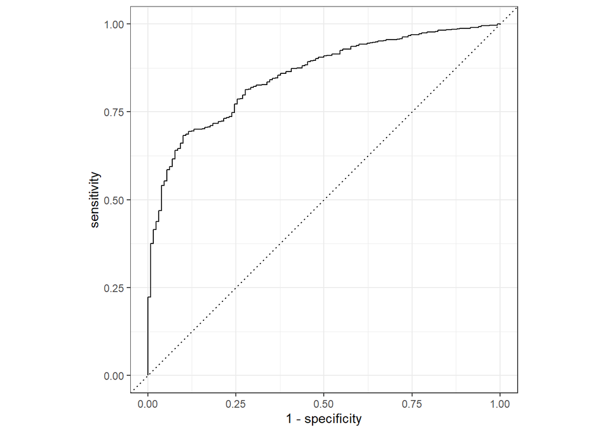

```r
nb_last_fit %>% collect_predictions() %>%
  roc_curve(truth  = y, estimate = .pred_no) %>%
  autoplot()
```

```r
nb_predictions <- nb_last_fit %>% collect_predictions()
conf_mat(nb_predictions, truth = y, estimate = .pred_class)
```

```
##           Truth
## Prediction  no yes
##        no  957  92
##        yes  43  38
```

```r
toc()
```

```
## 5.03 sec elapsed
```

### XGBoost

```r
tic()

bank_clean<-as.data.table(bank_clean)

set.seed(888)
xg_split<- initial_split(bank_clean)
xg_train<-training(xg_split)
xg_test<-testing(xg_split)

set.seed(888)
xg_folds<-vfold_cv(xg_train,v=10)

xgb_spec <- boost_tree(
  trees = 2000,
  tree_depth = tune(), min_n = tune(),
  loss_reduction = tune(),
  sample_size = tune(), mtry = tune(),
  learn_rate = tune()
) %>%
  set_engine("xgboost") %>%
  set_mode("classification")

xgb_spec
```

```
## Boosted Tree Model Specification (classification)
##
## Main Arguments:
##   mtry = tune()
##   trees = 2000
##   min_n = tune()
##   tree_depth = tune()
##   learn_rate = tune()
##   loss_reduction = tune()
##   sample_size = tune()
##
## Computational engine: xgboost
```

```r
xgb_grid <- grid_latin_hypercube(
  tree_depth(),
  min_n(),
  loss_reduction(),
  sample_size = sample_prop(),
  finalize(mtry(), xg_train),
  learn_rate(),
  size = 60
)

xgb_grid
```

```
## # A tibble: 60 x 6
##    tree_depth min_n loss_reduction sample_size  mtry   learn_rate
##         <int> <int>          <dbl>       <dbl> <int>        <dbl>
##  1         12    22       3.13e- 6       0.150     4 0.0000283
##  2          6     8       1.95e-10       0.883     3 0.00000810
##  3          6    36       1.33e+ 1       0.140     6 0.000316
##  4         14    27       5.43e- 6       0.280     5 0.00568
##  5          5    21       5.33e+ 0       0.390     7 0.000829
##  6         10    32       6.16e- 7       0.496     9 0.000000195
##  7          7    38       2.16e- 3       0.967    12 0.000000757
##  8          5    37       3.53e-10       0.307     4 0.00830
##  9          3     9       2.98e- 9       0.668     4 0.0208
## 10          7    29       2.83e- 4       0.446    14 0.0000000100
## # ... with 50 more rows
```

```r
xgb_recipe <- recipe(y ~ ., data = xg_train) %>%
  step_dummy(all_nominal(), -all_outcomes())




xgb_recipe %>%
  prep() %>%
  bake(new_data = xg_train)
```

```
## # A tibble: 3,391 x 72
##      age balance duration campaign pdays previous y     job_blue.collar
##    <int>   <int>    <int>    <int> <int>    <int> <fct>           <dbl>
##  1    30    1787       79        1    -1        0 no                  0
##  2    33    4789      220        1   339        4 no                  0
##  3    35     747      141        2   176        3 no                  0
##  4    36     307      341        1   330        2 no                  0
##  5    43     -88      313        1   147        2 no                  0
##  6    39    9374      273        1    -1        0 no                  0
##  7    43     264      113        2    -1        0 no                  0
##  8    20     502      261        1    -1        0 yes                 0
##  9    31     360       89        1   241        1 no                  1
## 10    40     194      189        2    -1        0 no                  0
## # ... with 3,381 more rows, and 64 more variables: job_entrepreneur <dbl>,
## #   job_housemaid <dbl>, job_management <dbl>, job_retired <dbl>,
## #   job_self.employed <dbl>, job_services <dbl>, job_student <dbl>,
## #   job_technician <dbl>, job_unemployed <dbl>, job_unknown <dbl>,
## #   marital_married <dbl>, marital_single <dbl>, education_secondary <dbl>,
## #   education_tertiary <dbl>, education_unknown <dbl>, default_yes <dbl>,
## #   housing_yes <dbl>, loan_yes <dbl>, contact_telephone <dbl>,
## #   contact_unknown <dbl>, day_X2 <dbl>, day_X3 <dbl>, day_X4 <dbl>,
## #   day_X5 <dbl>, day_X6 <dbl>, day_X7 <dbl>, day_X8 <dbl>, day_X9 <dbl>,
## #   day_X10 <dbl>, day_X11 <dbl>, day_X12 <dbl>, day_X13 <dbl>, day_X14 <dbl>,
## #   day_X15 <dbl>, day_X16 <dbl>, day_X17 <dbl>, day_X18 <dbl>, day_X19 <dbl>,
## #   day_X20 <dbl>, day_X21 <dbl>, day_X22 <dbl>, day_X23 <dbl>, day_X24 <dbl>,
## #   day_X25 <dbl>, day_X26 <dbl>, day_X27 <dbl>, day_X28 <dbl>, day_X29 <dbl>,
## #   day_X30 <dbl>, day_X31 <dbl>, month_aug <dbl>, month_dec <dbl>,
## #   month_feb <dbl>, month_jan <dbl>, month_jul <dbl>, month_jun <dbl>,
## #   month_mar <dbl>, month_may <dbl>, month_nov <dbl>, month_oct <dbl>,
## #   month_sep <dbl>, poutcome_other <dbl>, poutcome_success <dbl>,
## #   poutcome_unknown <dbl>
```

```r
xgb_wf <- workflow() %>%
  add_model(xgb_spec) %>%
  add_recipe(xgb_recipe)




library(doParallel)
cores<-detectCores()
cl<- makeCluster(cores[1]-4)
registerDoParallel(cl)


set.seed(888)
xgb_res <- tune_grid(
  xgb_wf,
  resamples = xg_folds,
  grid = xgb_grid,
  control = control_grid(save_pred = TRUE))

best_auc <- select_best(xgb_res, "roc_auc")



final_xgb <- finalize_workflow(
  xgb_wf,
  best_auc
)


final_res <- last_fit(final_xgb, xg_split)
collect_metrics(final_res)
```

```
## # A tibble: 2 x 4
##   .metric  .estimator .estimate .config
##   <chr>    <chr>          <dbl> <chr>
## 1 accuracy binary         0.912 Preprocessor1_Model1
## 2 roc_auc  binary         0.911 Preprocessor1_Model1
```

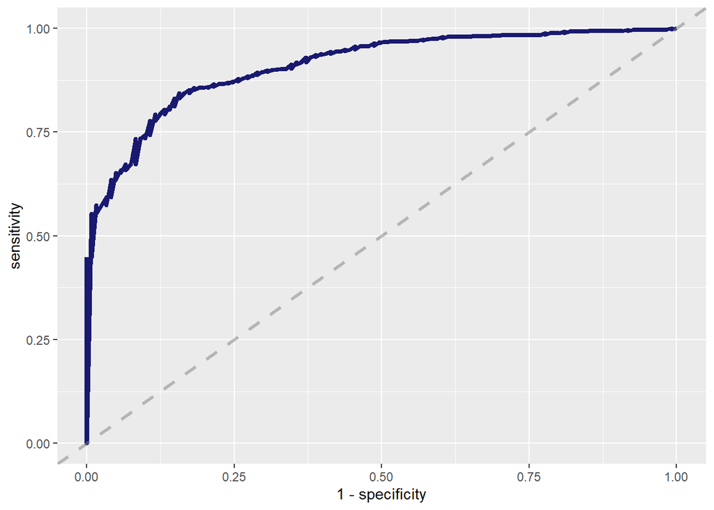

```r
final_res %>%
  collect_predictions() %>%
  roc_curve(y, .pred_no) %>%
  ggplot(aes(x = 1 - specificity, y = sensitivity)) +
  geom_line(size = 1.5, color = "midnightblue") +
  geom_abline(
    lty = 2, alpha = 0.5,
    color = "gray50",
    size = 1.2
  )
```

```r
final_res %>%
  collect_predictions() %>%
  conf_mat(truth = y, estimate = .pred_class)
```

```
##           Truth
## Prediction  no yes
##        no  991  82
##        yes  18  39
```

```r
library(vip)
final_xgb %>%
  fit(data = xg_train) %>%
  pull_workflow_fit() %>%
  vip(geom = "col")
```

```
## [01:21:33] WARNING: amalgamation/../src/learner.cc:1061: Starting in XGBoost 1.3.0, the default evaluation metric used with the objective 'binary:logistic' was changed from 'error' to 'logloss'. Explicitly set eval_metric if you'd like to restore the old behavior.
```

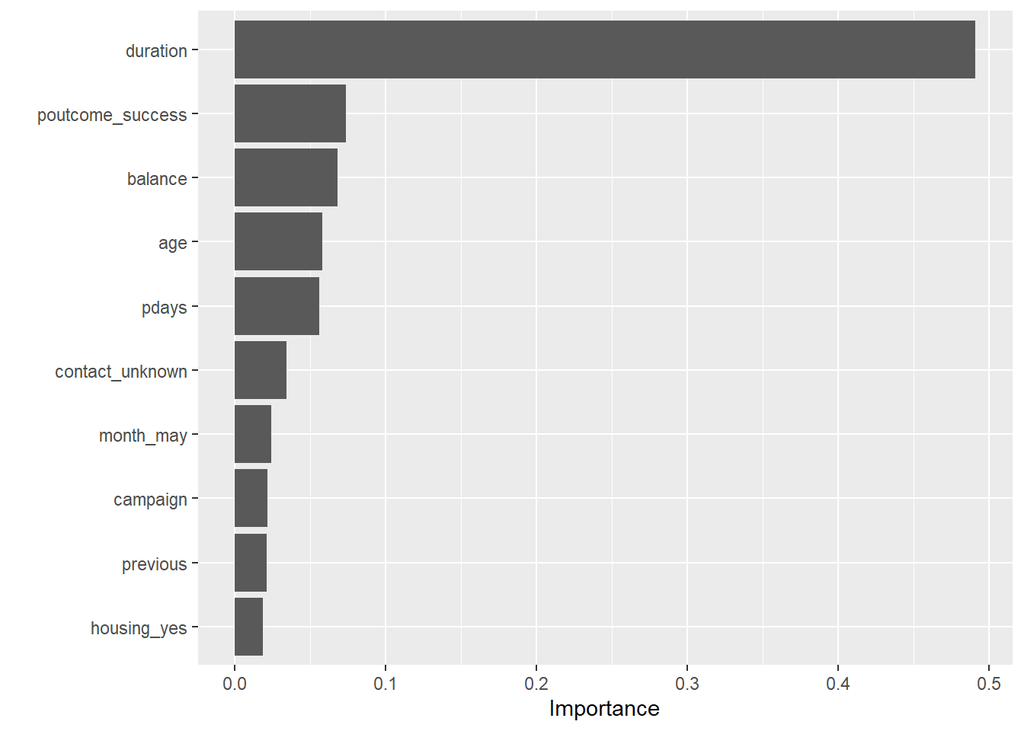

```r
toc()
```

```
## 1467.31 sec elapsed
```

### Initial Results

Examining the initial results of the models, we can see that we were able to achieve good results with all predictors being included in the model. With our tuned decision tree we were able to achieve a model accuracy of 87.61% and AUC of 81.61%. With our Naive Bayes model were were able to achieve an accuracy of 88.05% and AUC of 85.33%. We were able to out preform our first two models with our XGBoost model. This model achieved an accuracy of 91.15% and AUC of 91.10%.

```r
tic()
library("caret")
control <- rfeControl(functions = rfFuncs, # random forest
                      method = "repeatedcv", # repeated cv
                      repeats = 5, # number of repeats
                      number = 10) # number of folds

# Features
x <- bank_clean %>%
  select(-y) %>%
  as.data.frame()

# Target variable
y <- bank_clean$y

# Training: 80%; Test: 20%
set.seed(888)
inTrain <- createDataPartition(y, p = .80, list = FALSE)[,1]

x_train <- x[ inTrain, ]
x_test  <- x[-inTrain, ]

y_train <- y[ inTrain]
y_test  <- y[-inTrain]

result_rfe1 <- rfe(x = x_train,
                   y = y_train,
                   sizes = c(1:16),
                   rfeControl = control)

# Print the results
result_rfe1
```

```
##
## Recursive feature selection
##
## Outer resampling method: Cross-Validated (10 fold, repeated 5 times)
##
## Resampling performance over subset size:
##
##  Variables Accuracy  Kappa AccuracySD KappaSD Selected
##          1   0.8718 0.2158    0.01093 0.06216
##          2   0.8862 0.2294    0.01003 0.06863
##          3   0.8911 0.3579    0.01032 0.06903
##          4   0.8866 0.4165    0.01122 0.05803
##          5   0.8896 0.4188    0.01112 0.05140
##          6   0.8921 0.4204    0.01200 0.06102
##          7   0.8948 0.4247    0.01142 0.05663
##          8   0.8968 0.4197    0.01191 0.06319        *
##          9   0.8933 0.4491    0.01263 0.05555
##         10   0.8946 0.4528    0.01248 0.05921
##         11   0.8961 0.4544    0.01140 0.05469
##         12   0.8948 0.4351    0.01187 0.05443
##         13   0.8947 0.4260    0.01308 0.06053
##         14   0.8943 0.4130    0.01127 0.05631
##         15   0.8948 0.4064    0.01168 0.06725
##         16   0.8945 0.4289    0.01254 0.06224
##
## The top 5 variables (out of 8):
##    duration, month, day, poutcome, pdays
```

```r
# Print the selected features
predictors(result_rfe1)
```

```
## [1] "duration" "month"    "day"      "poutcome" "pdays"    "age"      "contact"
## [8] "previous"
```

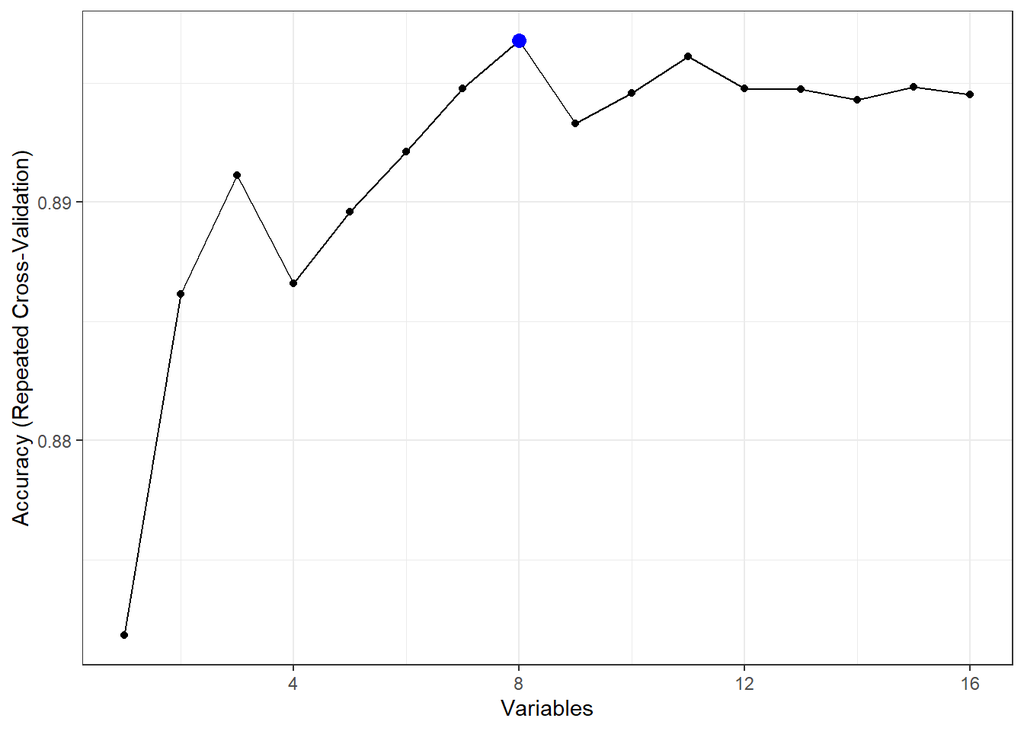

```r
# Print the results visually
ggplot(data = result_rfe1, metric = "Accuracy") + theme_bw()
```

```r
toc()
```

```
## 790.89 sec elapsed
```

### Re-training on selected features

#### Decision Tree

```r
###subsetting our selected features
bank_selected<-bank_clean[,c("duration","month","day","poutcome","pdays","age","contact","previous","y")]

###Decision Tree



tic()



set.seed(888)
bank_split <- initial_split(bank_selected, prop = 0.75,
                             strata = y)

bank_training <- bank_split %>% training()
bank_test <- bank_split %>% testing()
bank_folds <- vfold_cv(bank_training, v = 10)



bank_recipe <- recipe(y ~ ., data = bank_training) %>%
  step_YeoJohnson(all_numeric(),-all_predictors())



bank_clean_baked<-bank_recipe %>%
  prep() %>%
  bake(new_data = bank_training)

tree_model <- decision_tree(cost_complexity = tune(),
                            tree_depth = tune(),
                            min_n = tune()) %>%
  set_engine('rpart') %>%
  set_mode('classification')

tree_workflow <- workflow() %>%
  add_model(tree_model) %>%
  add_recipe(bank_recipe)

tree_grid <- grid_latin_hypercube(cost_complexity(),
                          tree_depth(),
                          min_n(),
                          size = 60)

set.seed(888)


tree_tuning <- tree_workflow %>%
  tune_grid(resamples = bank_folds,
            grid = tree_grid)


tree_tuning %>% show_best('roc_auc')
```

```
## # A tibble: 5 x 9
##   cost_complexity tree_depth min_n .metric .estimator  mean     n std_err
##             <dbl>      <int> <int> <chr>   <chr>      <dbl> <int>   <dbl>
## 1  0.000000365            13    25 roc_auc binary     0.845    10  0.0124
## 2  0.00000276             10    30 roc_auc binary     0.845    10  0.0123
## 3  0.000000000144         14    23 roc_auc binary     0.845    10  0.0122
## 4  0.0000000655           12    33 roc_auc binary     0.839    10  0.0117
## 5  0.000270               13    29 roc_auc binary     0.838    10  0.0153
## # ... with 1 more variable: .config <chr>
```

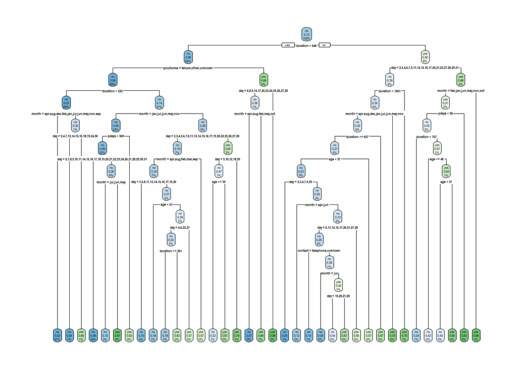

```r
best_tree <- tree_tuning %>%
  select_best(metric = 'roc_auc')


final_tree_workflow <- tree_workflow %>%
  finalize_workflow(best_tree)


tree_wf_fit <- final_tree_workflow %>%
  fit(data = bank_training)

tree_fit <- tree_wf_fit %>%
  pull_workflow_fit()


rpart.plot(tree_fit$fit, roundint = F)
```

```r
tree_last_fit <- final_tree_workflow %>%
  last_fit(bank_split)

tree_last_fit %>% collect_metrics()
```

```
## # A tibble: 2 x 4
##   .metric  .estimator .estimate .config
##   <chr>    <chr>          <dbl> <chr>
## 1 accuracy binary         0.892 Preprocessor1_Model1
## 2 roc_auc  binary         0.840 Preprocessor1_Model1
```

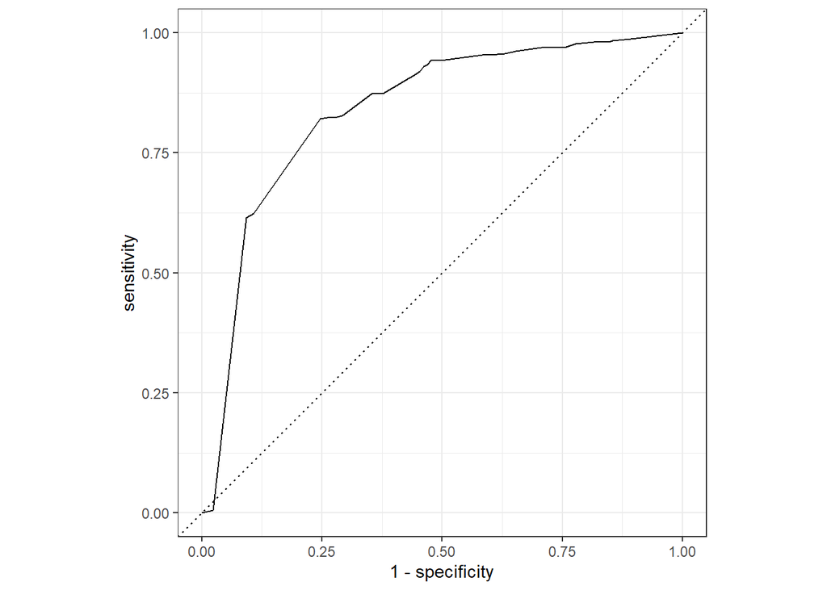

```r
tree_last_fit %>% collect_predictions() %>%
  roc_curve(truth  = y, estimate = .pred_no) %>%
  autoplot()
```

```r
tree_predictions <- tree_last_fit %>% collect_predictions()

conf_mat(tree_predictions, truth = y, estimate = .pred_class)
```

```
##           Truth
## Prediction  no yes
##        no  944  66
##        yes  56  64
```

```r
toc()
```

```
## 79.67 sec elapsed
```

#### Naive Bayes

```r
tic()

set.seed(888)
nb_split <- initial_split(bank_selected, prop = 0.75,
                            strata = y)

nb_training <- nb_split %>% training()
nb_test <- nb_split %>% testing()
nb_folds <- vfold_cv(nb_training, v = 10)

nb_recipe <- recipe(y ~ ., data = nb_training) %>%
  step_YeoJohnson(all_numeric(),-all_predictors())



nb_wf <- workflow() %>%
  add_recipe(nb_recipe)

library(discrim)
nb_spec <- naive_Bayes() %>%
  set_mode("classification") %>%
  set_engine("naivebayes")



nb_fit <- nb_wf %>%
  add_model(nb_spec) %>%
  fit(data = nb_training)

nb_wf_final <-  workflow() %>%
  add_recipe(nb_recipe) %>%
  add_model(nb_spec)

nb_rs <- fit_resamples(
  nb_wf_final,
  nb_folds,
  control = control_resamples(save_pred = TRUE)
)


nb_last_fit <- nb_wf_final %>%
  last_fit(nb_split)

nb_last_fit %>% collect_metrics()
```

```
## # A tibble: 2 x 4
##   .metric  .estimator .estimate .config
##   <chr>    <chr>          <dbl> <chr>
## 1 accuracy binary         0.884 Preprocessor1_Model1
## 2 roc_auc  binary         0.862 Preprocessor1_Model1
```

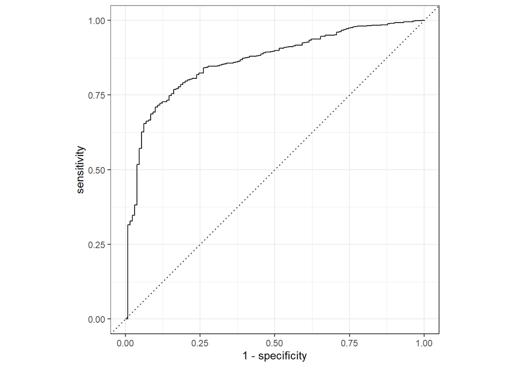

```r
nb_last_fit %>% collect_predictions() %>%
  roc_curve(truth  = y, estimate = .pred_no) %>%
  autoplot()
```

```r
nb_predictions <- nb_last_fit %>% collect_predictions()
conf_mat(nb_predictions, truth = y, estimate = .pred_class)
```

```
##           Truth
## Prediction  no yes
##        no  963  94
##        yes  37  36
```

```r
toc()
```

```
## 3.24 sec elapsed
```

#### XGBoost

```r
tic()

bank_selected<-as.data.table(bank_selected)

set.seed(888)
xg_split<- initial_split(bank_selected)
xg_train<-training(xg_split)
xg_test<-testing(xg_split)

set.seed(888)
xg_folds<-vfold_cv(xg_train,v=10)

xgb_spec <- boost_tree(
  trees = 2000,
  tree_depth = tune(), min_n = tune(),
  loss_reduction = tune(),
  sample_size = tune(), mtry = tune(),
  learn_rate = tune()
) %>%
  set_engine("xgboost") %>%
  set_mode("classification")



xgb_grid <- grid_latin_hypercube(
  tree_depth(),
  min_n(),
  loss_reduction(),
  sample_size = sample_prop(),
  finalize(mtry(), xg_train),
  learn_rate(),
  size = 60
)



xgb_recipe <- recipe(y ~ ., data = xg_train) %>%
  step_dummy(all_nominal(), -all_outcomes())




xgb_recipe %>%
  prep() %>%
  bake(new_data = xg_train)
```

```
## # A tibble: 3,391 x 51
##    duration pdays   age previous y     month_aug month_dec month_feb month_jan
##       <int> <int> <int>    <int> <fct>     <dbl>     <dbl>     <dbl>     <dbl>
##  1       79    -1    30        0 no            0         0         0         0
##  2      220   339    33        4 no            0         0         0         0
##  3      141   176    35        3 no            0         0         1         0
##  4      341   330    36        2 no            0         0         0         0
##  5      313   147    43        2 no            0         0         0         0
##  6      273    -1    39        0 no            0         0         0         0
##  7      113    -1    43        0 no            0         0         0         0
##  8      261    -1    20        0 yes           0         0         0         0
##  9       89   241    31        1 no            0         0         0         1
## 10      189    -1    40        0 no            1         0         0         0
## # ... with 3,381 more rows, and 42 more variables: month_jul <dbl>,
## #   month_jun <dbl>, month_mar <dbl>, month_may <dbl>, month_nov <dbl>,
## #   month_oct <dbl>, month_sep <dbl>, day_X2 <dbl>, day_X3 <dbl>, day_X4 <dbl>,
## #   day_X5 <dbl>, day_X6 <dbl>, day_X7 <dbl>, day_X8 <dbl>, day_X9 <dbl>,
## #   day_X10 <dbl>, day_X11 <dbl>, day_X12 <dbl>, day_X13 <dbl>, day_X14 <dbl>,
## #   day_X15 <dbl>, day_X16 <dbl>, day_X17 <dbl>, day_X18 <dbl>, day_X19 <dbl>,
## #   day_X20 <dbl>, day_X21 <dbl>, day_X22 <dbl>, day_X23 <dbl>, day_X24 <dbl>,
## #   day_X25 <dbl>, day_X26 <dbl>, day_X27 <dbl>, day_X28 <dbl>, day_X29 <dbl>,
## #   day_X30 <dbl>, day_X31 <dbl>, poutcome_other <dbl>, poutcome_success <dbl>,
## #   poutcome_unknown <dbl>, contact_telephone <dbl>, contact_unknown <dbl>
```

```r
xgb_wf <- workflow() %>%
  add_model(xgb_spec) %>%
  add_recipe(xgb_recipe)




library(doParallel)
cores<-detectCores()
cl<- makeCluster(cores[1]-4)
registerDoParallel(cl)


set.seed(888)
xgb_res <- tune_grid(
  xgb_wf,
  resamples = xg_folds,
  grid = xgb_grid,
  control = control_grid(save_pred = TRUE))

best_auc <- select_best(xgb_res, "roc_auc")



final_xgb <- finalize_workflow(
  xgb_wf,
  best_auc
)


final_res <- last_fit(final_xgb, xg_split)
collect_metrics(final_res)
```

```
## # A tibble: 2 x 4
##   .metric  .estimator .estimate .config
##   <chr>    <chr>          <dbl> <chr>
## 1 accuracy binary         0.907 Preprocessor1_Model1
## 2 roc_auc  binary         0.904 Preprocessor1_Model1
```

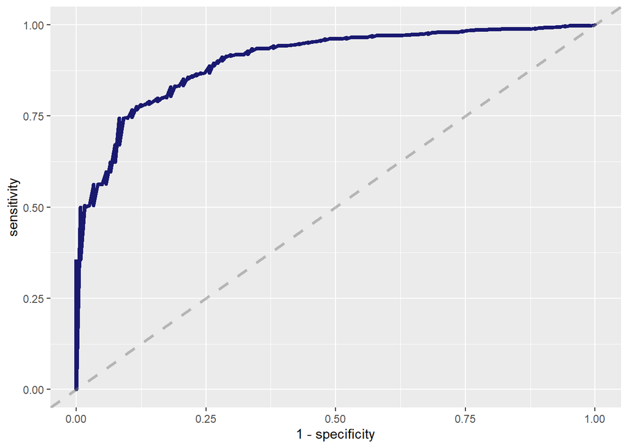

```r
final_res %>%
  collect_predictions() %>%
  roc_curve(y, .pred_no) %>%
  ggplot(aes(x = 1 - specificity, y = sensitivity)) +
  geom_line(size = 1.5, color = "midnightblue") +
  geom_abline(
    lty = 2, alpha = 0.5,
    color = "gray50",
    size = 1.2
  )
```

```r
final_res %>%
  collect_predictions() %>%
  conf_mat(truth = y, estimate = .pred_class)
```

```
##           Truth
## Prediction  no yes
##        no  989  85
##        yes  20  36
```

```r
toc()
```

```
## 1268.65 sec elapsed
```

Our model performance improved for both the Decision Tree and the Naive Bayes models. For the XGBoost model, limiting the number of predictors inputted into the model reduced performance.

## Conclusions and Recommendations

Based on our results we can conclude that feature selection can be an important activity to improve model performance with machine learning models such as Naive Bayes and Decision Trees. We were able to use several techniques to develop predictive models to predict if a customer would subscribe to one of client’s term deposit products with an overall accuracy of approximately 90%.

### Recomendations

It is recommended that our client implement a gradient boosting model such as the model developed as part of this report to pre-screen caller lists. If our client were able to restrict their outgoing calls to clients that our model predicts would be likely to subscribe to a term deposit product they would likely drastically improve their call conversion percentage, allowing them to get a much better ROI on their marketing spend. Additionally, reducing the volume of unwanted calls to clients not interested in term deposit products may improve their overall customer satisfaction.

## Appendix

###code

```r
knitr::opts_chunk$set(echo = TRUE)
library(knitr)
library(tidyverse)
library(tidymodels)
library(vip)
library(rpart.plot)
library(DataExplorer)
library(tictoc)
library(data.table)
library(gtools)
bank<-read.csv("https://raw.githubusercontent.com/PatLittle/CIND119-group-project/main/bank_marketing/bank.csv")
plot_intro(bank)
plot_str(bank, type="d")

job<-levels(as.factor(bank$job))
marital<-levels(as.factor(bank$marital))
education<-levels(as.factor(bank$education))
default<-levels(as.factor(bank$default))
housing<-levels(as.factor(bank$housing))
loan<-levels(as.factor(bank$loan))
contact<-levels(as.factor(bank$contact))
month<-levels(as.factor(bank$month))
poutcome<-levels(as.factor(bank$poutcome))
y<-levels(as.factor(bank$y))

na.pad <- function(x,len){
    x[1:len]
}

makePaddedDataFrame <- function(l,...){
    maxlen <- max(sapply(l,length))
    data.frame(lapply(l,na.pad,len=maxlen),...)
}

a = job
b = marital
c = education
d = default
e = loan
f = contact
g = month
h = poutcome
j = y

data_dict<-makePaddedDataFrame(list("Job"=a,"Marital"=b,"Education"=c,"Default"=d,"Loan"=e,"Contact"=f,"Month"=g,"pOutcome"=h,"y"=j))

data_dict %>% na.replace("")
options(knitr.kable.NA = '')
kable(data_dict, caption="Character Variables with all Existing Values")
bank_clean<- bank %>% mutate_if(is.character, factor)



require(rcompanion)


# Calculate a pairwise association between all variables in a data-frame. In particular nominal vs nominal with Chi-square, numeric vs numeric with Spearman correlation, and nominal vs numeric with ANOVA.
# Adopted from https://stackoverflow.com/a/52557631/590437
mixed_assoc = function(df, cor_method="spearman", adjust_cramersv_bias=TRUE){
    df_comb = expand.grid(names(df), names(df),  stringsAsFactors = F) %>% set_names("X1", "X2")

    is_nominal = function(x) class(x) %in% c("factor", "character")
    # https://community.rstudio.com/t/why-is-purr-is-numeric-deprecated/3559
    # https://github.com/r-lib/rlang/issues/781
    is_numeric <- function(x) { is.integer(x) || is_double(x)}

    f = function(xName,yName) {
        x =  pull(df, xName)
        y =  pull(df, yName)

        result = if(is_nominal(x) && is_nominal(y)){
            # use bias corrected cramersV as described in https://rdrr.io/cran/rcompanion/man/cramerV.html
            cv = cramerV(as.character(x), as.character(y), bias.correct = adjust_cramersv_bias)
            data.frame(xName, yName, assoc=cv, type="cramersV")

        }else if(is_numeric(x) && is_numeric(y)){
            correlation = cor(x, y, method=cor_method, use="complete.obs")
            data.frame(xName, yName, assoc=correlation, type="correlation")

        }else if(is_numeric(x) && is_nominal(y)){
            # from https://stats.stackexchange.com/questions/119835/correlation-between-a-nominal-iv-and-a-continuous-dv-variable/124618#124618
            r_squared = summary(lm(x ~ y))$r.squared
            data.frame(xName, yName, assoc=sqrt(r_squared), type="anova")

        }else if(is_nominal(x) && is_numeric(y)){
            r_squared = summary(lm(y ~x))$r.squared
            data.frame(xName, yName, assoc=sqrt(r_squared), type="anova")

        }else {
            warning(paste("unmatched column type combination: ", class(x), class(y)))
        }

        # finally add complete obs number and ratio to table
        result %>% mutate(complete_obs_pairs=sum(!is.na(x) & !is.na(y)), complete_obs_ratio=complete_obs_pairs/length(x)) %>% rename(x=xName, y=yName)
    }

    # apply function to each variable combination
    map2_df(df_comb$X1, df_comb$X2, f)
}

cor_data<-mixed_assoc(bank_clean) %>% subset(assoc<0.99999) %>% arrange(desc(abs(assoc)))
kable(cor_data[1:16,1:4],row.names = F, caption = "Mixed Data Types Correlation/Association")
plot_correlation(bank_clean, type = "c", cor_args = list("method"="pearson"))

kable(summary(bank_clean))


plot_boxplot(bank_clean, by="y")

age_out<-boxplot(bank_clean$age,plot=F)$out
bal_out<-boxplot(bank_clean$balance,plot=F)$out
campaign_out<-boxplot(bank_clean$campaign,plot=F)$out
duration_out<-boxplot(bank_clean$duration,plot=F)$out
pdays_out<-boxplot(bank_clean$pdays,plot=F)$out
prev_out<-boxplot(bank_clean$previous,plot=F)$out

bank_clean <- bank_clean[-which(bank_clean$age %in% age_out),]
bank_clean <- bank_clean[-which(bank_clean$balance %in% bal_out),]
bank_clean <- bank_clean[-which(bank_clean$campaign %in% campaign_out),]
bank_clean <- bank_clean[-which(bank_clean$duration %in% duration_out),]
bank_clean <- bank_clean[-which(bank_clean$pdays %in% pdays_out),]
bank_clean <- bank_clean[-which(bank_clean$previous %in% prev_out),]

head(bank_clean)


bank_clean<- bank %>% mutate_if(is.character, factor)
bank_clean$day<-as.factor(bank_clean$day)

###Decision Tree


tic()


set.seed(888)
bank_split <- initial_split(bank_clean, prop = 0.75,
                             strata = y)

bank_training <- bank_split %>% training()
bank_test <- bank_split %>% testing()
bank_folds <- vfold_cv(bank_training, v = 10)



bank_recipe <- recipe(y ~ ., data = bank_training) %>%
  step_YeoJohnson(all_numeric(),-all_predictors())



bank_clean_baked<-bank_recipe %>%
  prep() %>%
  bake(new_data = bank_training)

tree_model <- decision_tree(cost_complexity = tune(),
                            tree_depth = tune(),
                            min_n = tune()) %>%
  set_engine('rpart') %>%
  set_mode('classification')

tree_workflow <- workflow() %>%
  add_model(tree_model) %>%
  add_recipe(bank_recipe)

tree_grid <- grid_latin_hypercube(cost_complexity(),
                          tree_depth(),
                          min_n(),
                          size = 60)

set.seed(888)


tree_tuning <- tree_workflow %>%
  tune_grid(resamples = bank_folds,
            grid = tree_grid)


tree_tuning %>% show_best('roc_auc')

best_tree <- tree_tuning %>%
  select_best(metric = 'roc_auc')


final_tree_workflow <- tree_workflow %>%
  finalize_workflow(best_tree)


tree_wf_fit <- final_tree_workflow %>%
  fit(data = bank_training)
```

```r
tree_fit <- tree_wf_fit %>%
  pull_workflow_fit()


rpart.plot(tree_fit$fit, roundint = F)

tree_last_fit <- final_tree_workflow %>%
  last_fit(bank_split)

tree_last_fit %>% collect_metrics()


tree_last_fit %>% collect_predictions() %>%
  roc_curve(truth  = y, estimate = .pred_no) %>%
  autoplot()

tree_predictions <- tree_last_fit %>% collect_predictions()

conf_mat(tree_predictions, truth = y, estimate = .pred_class)

toc()


tic()

set.seed(888)
nb_split <- initial_split(bank_clean, prop = 0.75,
                            strata = y)

nb_training <- nb_split %>% training()
nb_test <- nb_split %>% testing()
nb_folds <- vfold_cv(nb_training, v = 10)

nb_recipe <- recipe(y ~ ., data = nb_training) %>%
  step_YeoJohnson(all_numeric(),-all_predictors())



nb_wf <- workflow() %>%
  add_recipe(nb_recipe)

library(discrim)
nb_spec <- naive_Bayes() %>%
  set_mode("classification") %>%
  set_engine("naivebayes")

nb_spec

nb_fit <- nb_wf %>%
  add_model(nb_spec) %>%
  fit(data = nb_training)

nb_wf_final <-  workflow() %>%
  add_recipe(nb_recipe) %>%
  add_model(nb_spec)

nb_rs <- fit_resamples(
  nb_wf_final,
  nb_folds,
  control = control_resamples(save_pred = TRUE)
)


nb_last_fit <- nb_wf_final %>%
  last_fit(nb_split)

nb_last_fit %>% collect_metrics()

nb_last_fit %>% collect_predictions() %>%
  roc_curve(truth  = y, estimate = .pred_no) %>%
  autoplot()

nb_predictions <- nb_last_fit %>% collect_predictions()
conf_mat(nb_predictions, truth = y, estimate = .pred_class)

toc()

tic()

bank_clean<-as.data.table(bank_clean)

set.seed(888)
xg_split<- initial_split(bank_clean)
xg_train<-training(xg_split)
xg_test<-testing(xg_split)

set.seed(888)
xg_folds<-vfold_cv(xg_train,v=10)

xgb_spec <- boost_tree(
  trees = 2000,
  tree_depth = tune(), min_n = tune(),
  loss_reduction = tune(),
  sample_size = tune(), mtry = tune(),
  learn_rate = tune()
) %>%
  set_engine("xgboost") %>%
  set_mode("classification")

xgb_spec

xgb_grid <- grid_latin_hypercube(
  tree_depth(),
  min_n(),
  loss_reduction(),
  sample_size = sample_prop(),
  finalize(mtry(), xg_train),
  learn_rate(),
  size = 60
)

xgb_grid

xgb_recipe <- recipe(y ~ ., data = xg_train) %>%
  step_dummy(all_nominal(), -all_outcomes())




xgb_recipe %>%
  prep() %>%
  bake(new_data = xg_train)



xgb_wf <- workflow() %>%
  add_model(xgb_spec) %>%
  add_recipe(xgb_recipe)




library(doParallel)
cores<-detectCores()
cl<- makeCluster(cores[1]-4)
registerDoParallel(cl)


set.seed(888)
xgb_res <- tune_grid(
  xgb_wf,
  resamples = xg_folds,
  grid = xgb_grid,
  control = control_grid(save_pred = TRUE))

best_auc <- select_best(xgb_res, "roc_auc")



final_xgb <- finalize_workflow(
  xgb_wf,
  best_auc
)


final_res <- last_fit(final_xgb, xg_split)
collect_metrics(final_res)


final_res %>%
  collect_predictions() %>%
  roc_curve(y, .pred_no) %>%
  ggplot(aes(x = 1 - specificity, y = sensitivity)) +
  geom_line(size = 1.5, color = "midnightblue") +
  geom_abline(
    lty = 2, alpha = 0.5,
    color = "gray50",
    size = 1.2
  )


final_res %>%
  collect_predictions() %>%
  conf_mat(truth = y, estimate = .pred_class)

library(vip)
final_xgb %>%
  fit(data = xg_train) %>%
  pull_workflow_fit() %>%
  vip(geom = "col")

toc()
tic()
library("caret")
control <- rfeControl(functions = rfFuncs, # random forest
                      method = "repeatedcv", # repeated cv
                      repeats = 5, # number of repeats
                      number = 10) # number of folds

# Features
x <- bank_clean %>%
  select(-y) %>%
  as.data.frame()

# Target variable
y <- bank_clean$y

# Training: 80%; Test: 20%
set.seed(888)
inTrain <- createDataPartition(y, p = .80, list = FALSE)[,1]

x_train <- x[ inTrain, ]
x_test  <- x[-inTrain, ]

y_train <- y[ inTrain]
y_test  <- y[-inTrain]

result_rfe1 <- rfe(x = x_train,
                   y = y_train,
                   sizes = c(1:16),
                   rfeControl = control)

# Print the results
result_rfe1

# Print the selected features
predictors(result_rfe1)

# Print the results visually
ggplot(data = result_rfe1, metric = "Accuracy") + theme_bw()

toc()
###subsetting our selected features
bank_selected<-bank_clean[,c("duration","month","day","poutcome","pdays","age","contact","previous","y")]

###Decision Tree



tic()



set.seed(888)
bank_split <- initial_split(bank_selected, prop = 0.75,
                             strata = y)

bank_training <- bank_split %>% training()
bank_test <- bank_split %>% testing()
bank_folds <- vfold_cv(bank_training, v = 10)



bank_recipe <- recipe(y ~ ., data = bank_training) %>%
  step_YeoJohnson(all_numeric(),-all_predictors())



bank_clean_baked<-bank_recipe %>%
  prep() %>%
  bake(new_data = bank_training)

tree_model <- decision_tree(cost_complexity = tune(),
                            tree_depth = tune(),
                            min_n = tune()) %>%
  set_engine('rpart') %>%
  set_mode('classification')

tree_workflow <- workflow() %>%
  add_model(tree_model) %>%
  add_recipe(bank_recipe)

tree_grid <- grid_latin_hypercube(cost_complexity(),
                          tree_depth(),
                          min_n(),
                          size = 60)

set.seed(888)


tree_tuning <- tree_workflow %>%
  tune_grid(resamples = bank_folds,
            grid = tree_grid)


tree_tuning %>% show_best('roc_auc')

best_tree <- tree_tuning %>%
  select_best(metric = 'roc_auc')


final_tree_workflow <- tree_workflow %>%
  finalize_workflow(best_tree)


tree_wf_fit <- final_tree_workflow %>%
  fit(data = bank_training)

tree_fit <- tree_wf_fit %>%
  pull_workflow_fit()


rpart.plot(tree_fit$fit, roundint = F)

tree_last_fit <- final_tree_workflow %>%
  last_fit(bank_split)

tree_last_fit %>% collect_metrics()


tree_last_fit %>% collect_predictions() %>%
  roc_curve(truth  = y, estimate = .pred_no) %>%
  autoplot()

tree_predictions <- tree_last_fit %>% collect_predictions()

conf_mat(tree_predictions, truth = y, estimate = .pred_class)

toc()


tic()

set.seed(888)
nb_split <- initial_split(bank_selected, prop = 0.75,
                            strata = y)
```

```r
nb_training <- nb_split %>% training()
nb_test <- nb_split %>% testing()
nb_folds <- vfold_cv(nb_training, v = 10)

nb_recipe <- recipe(y ~ ., data = nb_training) %>%
  step_YeoJohnson(all_numeric(),-all_predictors())



nb_wf <- workflow() %>%
  add_recipe(nb_recipe)

library(discrim)
nb_spec <- naive_Bayes() %>%
  set_mode("classification") %>%
  set_engine("naivebayes")



nb_fit <- nb_wf %>%
  add_model(nb_spec) %>%
  fit(data = nb_training)

nb_wf_final <-  workflow() %>%
  add_recipe(nb_recipe) %>%
  add_model(nb_spec)

nb_rs <- fit_resamples(
  nb_wf_final,
  nb_folds,
  control = control_resamples(save_pred = TRUE)
)


nb_last_fit <- nb_wf_final %>%
  last_fit(nb_split)

nb_last_fit %>% collect_metrics()

nb_last_fit %>% collect_predictions() %>%
  roc_curve(truth  = y, estimate = .pred_no) %>%
  autoplot()

nb_predictions <- nb_last_fit %>% collect_predictions()
conf_mat(nb_predictions, truth = y, estimate = .pred_class)

toc()

tic()

bank_selected<-as.data.table(bank_selected)

set.seed(888)
xg_split<- initial_split(bank_selected)
xg_train<-training(xg_split)
xg_test<-testing(xg_split)

set.seed(888)
xg_folds<-vfold_cv(xg_train,v=10)

xgb_spec <- boost_tree(
  trees = 2000,
  tree_depth = tune(), min_n = tune(),
  loss_reduction = tune(),
  sample_size = tune(), mtry = tune(),
  learn_rate = tune()
) %>%
  set_engine("xgboost") %>%
  set_mode("classification")



xgb_grid <- grid_latin_hypercube(
  tree_depth(),
  min_n(),
  loss_reduction(),
  sample_size = sample_prop(),
  finalize(mtry(), xg_train),
  learn_rate(),
  size = 60
)



xgb_recipe <- recipe(y ~ ., data = xg_train) %>%
  step_dummy(all_nominal(), -all_outcomes())




xgb_recipe %>%
  prep() %>%
  bake(new_data = xg_train)



xgb_wf <- workflow() %>%
  add_model(xgb_spec) %>%
  add_recipe(xgb_recipe)




library(doParallel)
cores<-detectCores()
cl<- makeCluster(cores[1]-4)
registerDoParallel(cl)


set.seed(888)
xgb_res <- tune_grid(
  xgb_wf,
  resamples = xg_folds,
  grid = xgb_grid,
  control = control_grid(save_pred = TRUE))

best_auc <- select_best(xgb_res, "roc_auc")



final_xgb <- finalize_workflow(
  xgb_wf,
  best_auc
)


final_res <- last_fit(final_xgb, xg_split)
collect_metrics(final_res)


final_res %>%
  collect_predictions() %>%
  roc_curve(y, .pred_no) %>%
  ggplot(aes(x = 1 - specificity, y = sensitivity)) +
  geom_line(size = 1.5, color = "midnightblue") +
  geom_abline(
    lty = 2, alpha = 0.5,
    color = "gray50",
    size = 1.2
  )


final_res %>%
  collect_predictions() %>%
  conf_mat(truth = y, estimate = .pred_class)


toc()
# this R markdown chunk generates a code appendix
```